# Assignment 4

Jeff Gould

3/30/2021

# Analysis

## 1

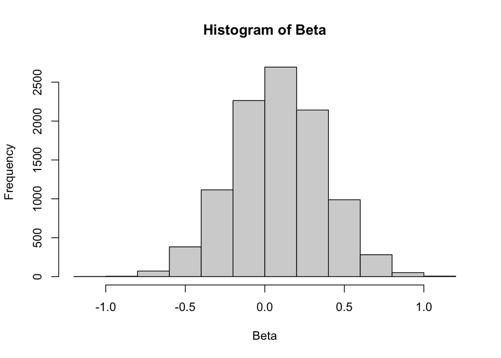

```r
forestfire <- read.delim("forestfire.txt")
n <- nrow(forestfire)

beta_hat <- log(sum(forestfire) / (n - sum(forestfire)))
var <- ((n * exp(beta_hat)) / (1 + exp(beta_hat)) - (2 * n * exp(beta_hat)) / ((1 + exp(beta_hat))^2))^(-1)


set.seed(812)
Beta <- rnorm(10000, mean = beta_hat, sd = sqrt(var))
hist(Beta)
```

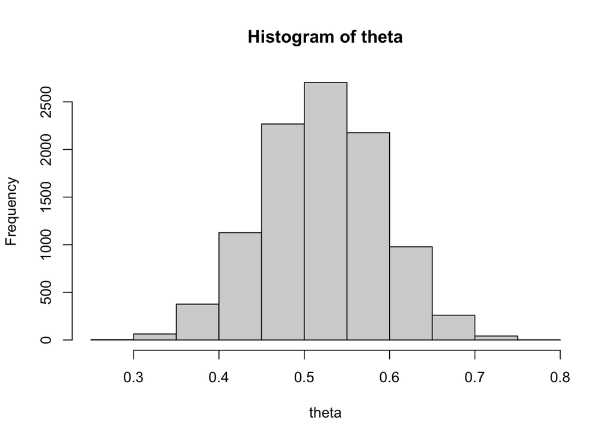

```r
theta <- exp(Beta) / ( 1+ exp(Beta))

hist(theta)
```

Jeffrey’s Prior

$\pi(\theta) \propto [J(\theta)]^{1/2}$

$J[\theta] = - E\left[ \frac{\partial^2\log \mathcal{L}(Y|\theta)}{\partial^2 \theta} | \theta \right]$

$\mathcal{L} \propto \exp \left\{\sum_{i=1}^n y_i \beta - \log(1 + e^{\beta}) \right\}$

$\log \mathcal{L} \propto \sum_{i=1}^n y_i \beta - \log(1 + e^{\beta}) = \sum y_i \beta - n \log(1 + e^\beta)$

$\frac{\partial \log \mathcal{L}}{\partial \beta} = \sum y_i - \frac{n e^\beta}{1 + e^\beta}$

$\frac{\partial^2}{\partial \beta^2} = \frac{n e^\beta}{1 + e^\beta} - \frac{ne^{2\beta}}{(1 + e^\beta)^2} = \frac{n e^{\beta}}{(1 + e^\beta)^2}$

$J(\theta) = -E \left[ \frac{n e^{\beta}}{(1 + e^\beta)^2} | \beta \right] = \frac{n e^{\beta}}{(1 + e^\beta)^2}$

$\pi(\beta) \propto \left( \frac{n e^{\beta}}{(1 + e^\beta)^2} \right)^{1/2} \propto \frac{e^{\beta/2}}{1 + e^\beta}$

$P(\beta|Y) \propto \exp\{\sum y_i\beta - \log(1 + e^\beta) \}\frac{e^{\beta/2}}{1 + e^\beta}$

Take the log:

$\sum (y_i\beta) - n\log(1 + e^\beta) + \log \left( \frac{e^{\beta/2}}{1 + e^\beta}\right) = \sum (y_i\beta) - n\log(1 + e^\beta) +\frac{\beta}{2} - \log(1 + e^\beta) = \sum ( y_i \beta) - (n+1)\log(1 + e^\beta) + \frac{\beta}{2}$

$\frac{\partial \mathcal{l}}{\partial \beta} = \sum y_i - \frac{(n+1)e^\beta}{1 + e^\beta} + \frac{1}{2} \overset{set}{=}0$

$$\begin{align*}
\begin{split}
\sum y_i + \frac{1}{2} &= \frac{(n+1)e^\beta}{1 + e^\beta} \\
(n+1)e^\beta &= (1 + e^\beta)(\sum y_i + 1/2) = \sum y_i + 1/2 + e^\beta \sum y_i + e^\beta/2 \\
e^\beta(n+1) - e^\beta\sum y_i - e^\beta(1/2) &= \sum y_i + 1/2 \\
e^\beta &= \frac{\sum y_i + 1/2}{(n+1) - \sum y_i - 1/2} \\
\hat{\beta} &= \log \left(\frac{\sum y_i + 1/2}{(n+1) - \sum y_i - 1/2} \right)
\end{split}
\end{align*}$$

$$\begin{align*}
\begin{split}
\frac{\partial^2}{\partial \beta^2} &= [(n+1)e^\beta][-1(1+e^\beta)^{-2}e^\beta] + [(1 + e^\beta)^{-1}][(n+1)e^\beta] \\
&=\frac{(n+1)e^\beta}{1 + e^\beta} - \frac{(n+1)e^{2\beta}}{(1 + e^\beta)^2} \\
&=\frac{(n+1)e^\beta}{(1 + e^\beta)^2}
\end{split}
\end{align*}$$

$I(\hat{\beta}) = -\frac{d^2}{d \beta^2}\log[p(\beta | y)] = \frac{(n+1)e^\hat{\beta}}{(1 + e^\hat{\beta})^2}$

$$P(\beta | y) \overset{\cdot}{\sim} \mathcal{N} \left(\log \left(\frac{\sum y_i + 1/2}{(n+1) - \sum y_i - 1/2} \right), \frac{(1 + e^\hat{\beta})^2}{(n+1)e^\hat{\beta}}\right)$$

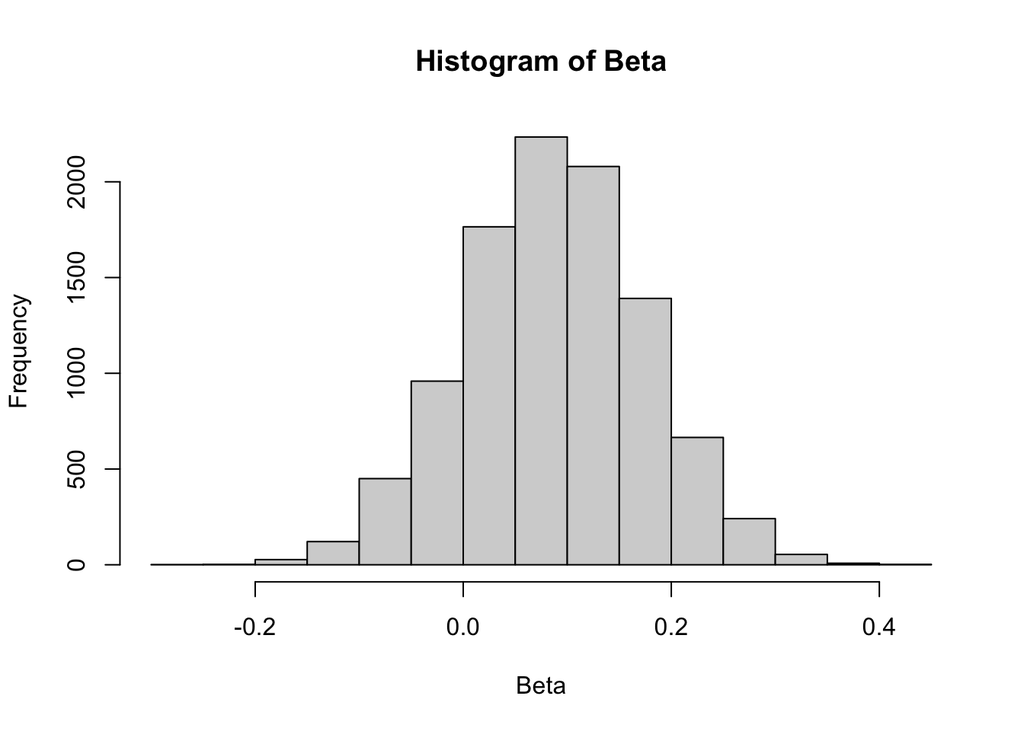

```r
beta_hat <- log(
  (sum(forestfire) + 1/2) / (n+1 - sum(forestfire) - 1/2)
  )
var <- ((1 + exp(beta_hat))^2) / ((n+1) * exp(beta_hat))


set.seed(812)
Beta <- rnorm(10000, mean = beta_hat, sd = sqrt(var))
hist(Beta)
```

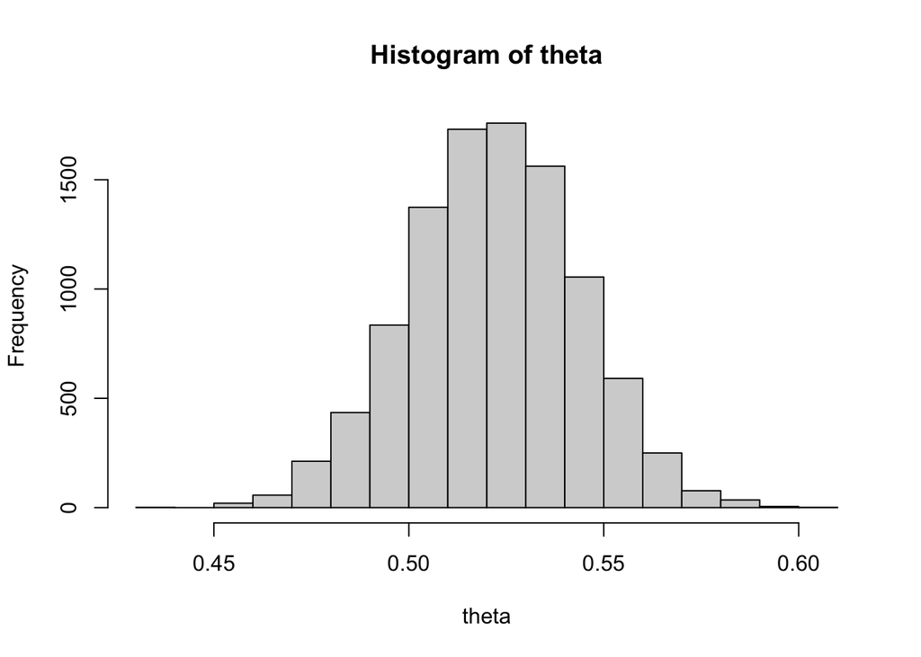

```r
theta <- exp(Beta) / ( 1+ exp(Beta))

hist(theta)
```

## 2

```r
library(mvtnorm)
bikeshare <- read.table("bikeshare.txt", header = T)

casual_model_1 <- glm(casual ~ yr  + workingday  + atemp + hum  + holiday + temp + windspeed,
                      data = bikeshare, family = poisson(link = "log"))
summary(casual_model_1)
```

```
##
## Call:
## glm(formula = casual ~ yr + workingday + atemp + hum + holiday +
##     temp + windspeed, family = poisson(link = "log"), data = bikeshare)
##
## Deviance Residuals:
##     Min       1Q   Median       3Q      Max
## -53.563   -9.164   -1.384    5.818   44.896
##
## Coefficients:
##              Estimate Std. Error  z value Pr(>|z|)
## (Intercept)  6.293572   0.009885  636.705  < 2e-16 ***
## yr           0.353792   0.002611  135.496  < 2e-16 ***
## workingday  -0.876070   0.002590 -338.285  < 2e-16 ***
## atemp        2.347946   0.075263   31.196  < 2e-16 ***
## hum         -0.730709   0.009925  -73.624  < 2e-16 ***
## holiday     -0.244973   0.006946  -35.270  < 2e-16 ***
## temp         0.469600   0.066165    7.097 1.27e-12 ***
## windspeed   -1.170926   0.018862  -62.079  < 2e-16 ***
## ---
## Signif. codes:  0 '***' 0.001 '**' 0.01 '*' 0.05 '.' 0.1 ' ' 1
##
## (Dispersion parameter for poisson family taken to be 1)
##
##     Null deviance: 378438  on 730  degrees of freedom
## Residual deviance: 111688  on 723  degrees of freedom
## AIC: 117688
##
## Number of Fisher Scoring iterations: 5
```

```r
bhat    <- coef(casual_model_1)
vbeta   <- vcov(casual_model_1)
B       <- 10000
set.seed(1959)
beta    <- rmvnorm(B, mean = bhat, sigma = vbeta)

round(t(apply(beta, 2, quantile, probs = c(0.5, 0.025, 0.975))), 4)
```

```
##                 50%    2.5%   97.5%
## (Intercept)  6.2937  6.2744  6.3124
## yr           0.3538  0.3486  0.3589
## workingday  -0.8761 -0.8812 -0.8709
## atemp        2.3490  2.2006  2.4972
## hum         -0.7308 -0.7496 -0.7112
## holiday     -0.2451 -0.2585 -0.2314
## temp         0.4692  0.3386  0.5990
## windspeed   -1.1710 -1.2075 -1.1339
```

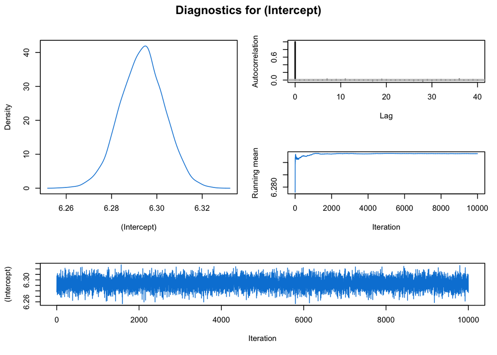

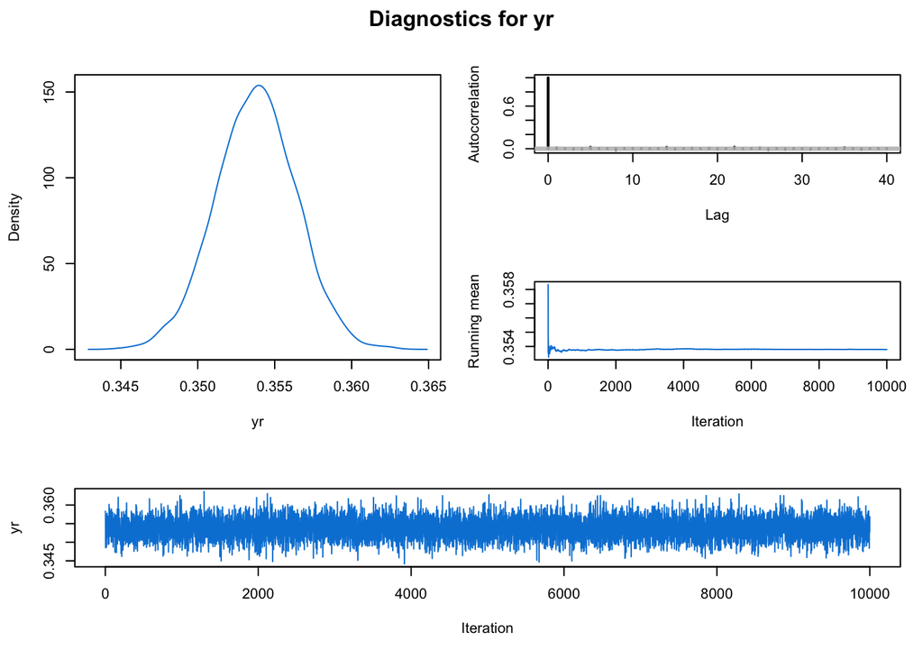

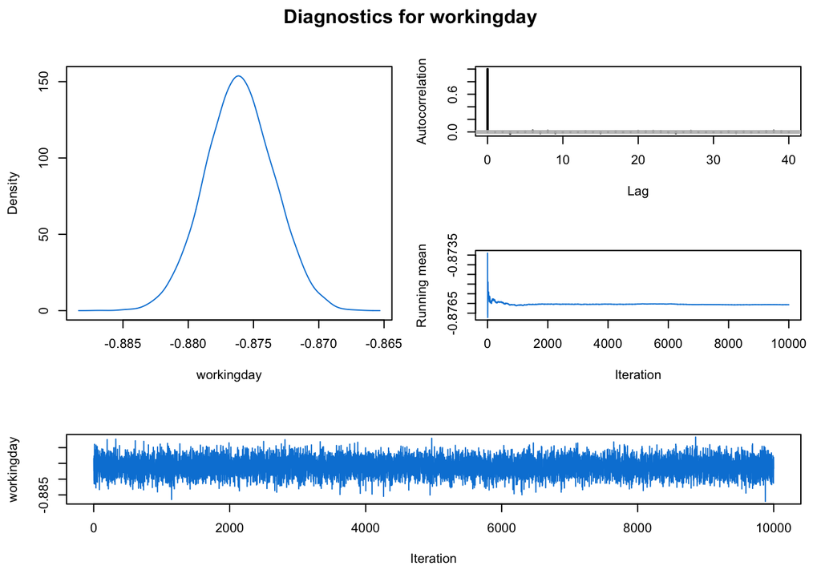

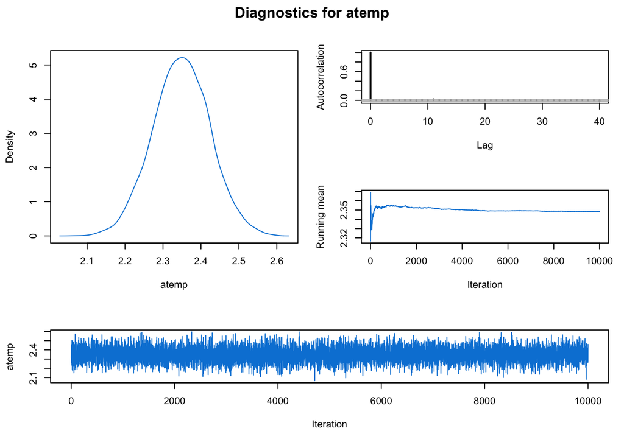

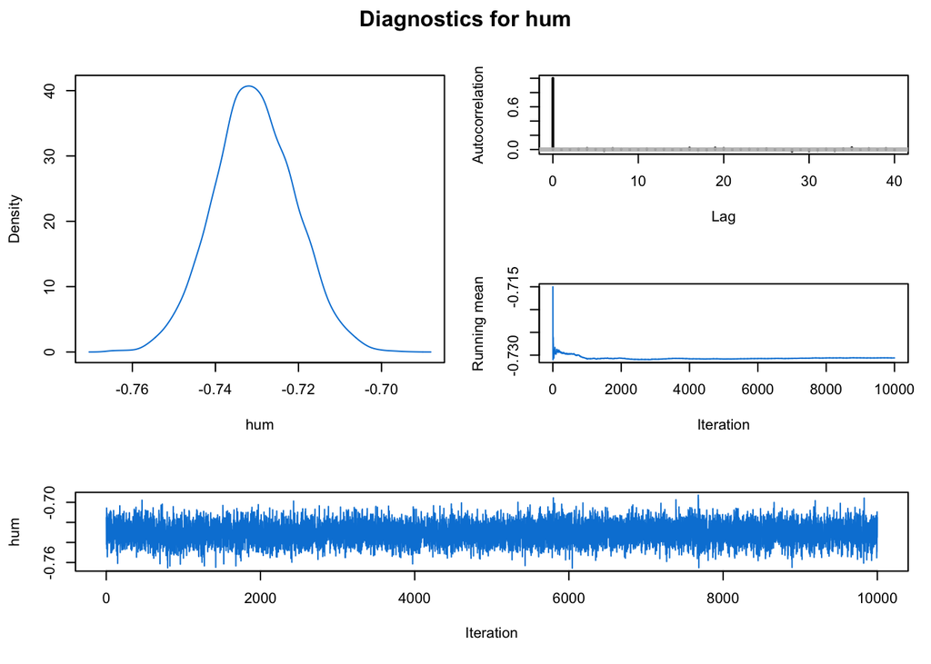

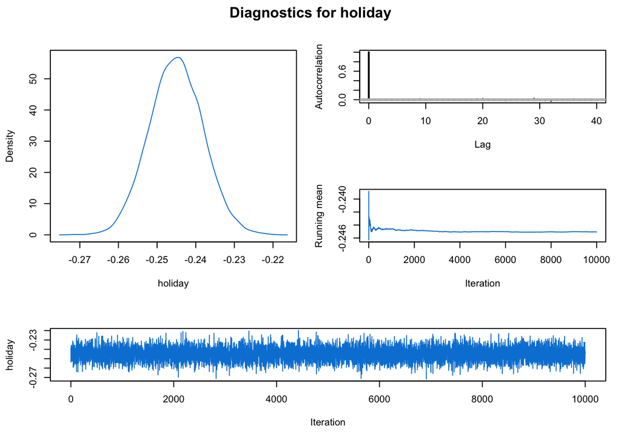

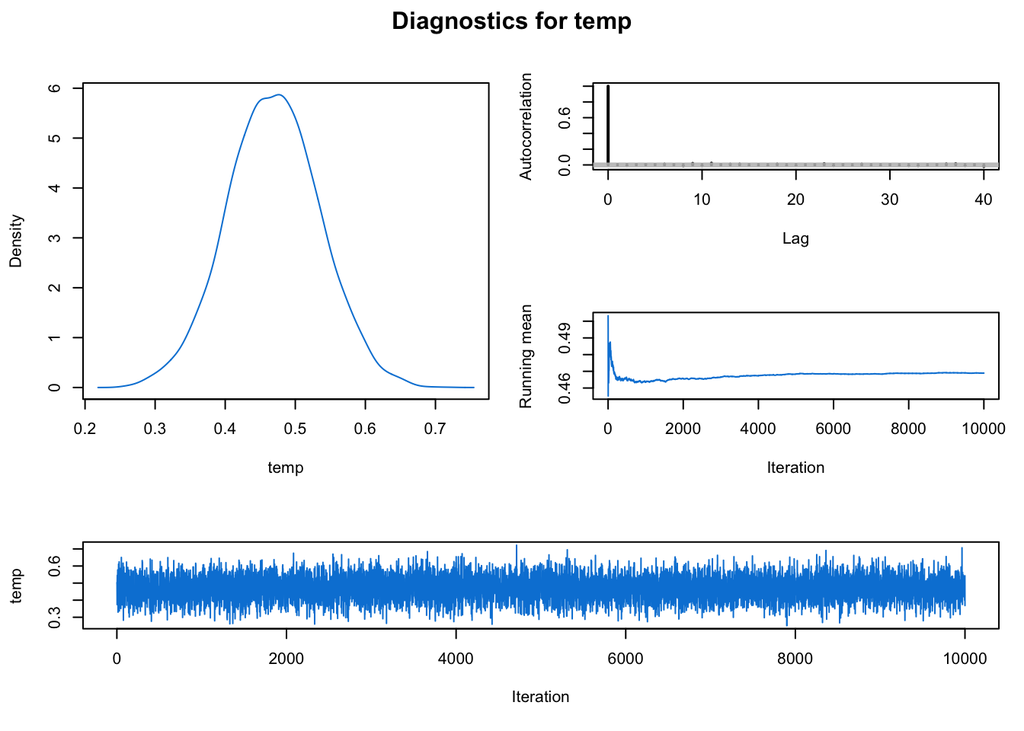

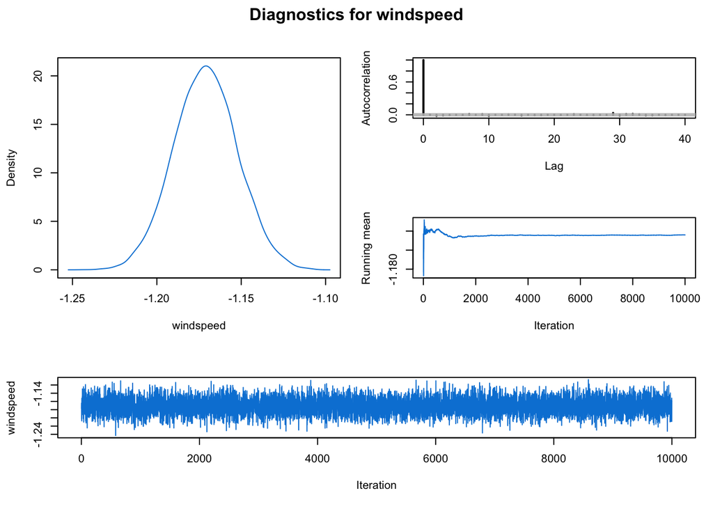

```r
library(mcmcplots)

for (v in colnames(beta)) {
  x <- data.frame(var = beta[,v])
  colnames(x) <- v
  mcmcplot1(x, style = "plain")
}
```

```r
geweke.diag(mcmc(beta))
```

```
##
## Fraction in 1st window = 0.1
## Fraction in 2nd window = 0.5
##
## (Intercept)          yr  workingday       atemp         hum     holiday
##   -0.001961   -0.507642    0.208877    2.740018   -1.213445    2.092198
##        temp   windspeed
##   -2.633174   -0.699617
```

# Theoretical

## 1

$\mathcal{L}(y | \lambda) = \prod \frac{\lambda^{y_i}e^{-\lambda}}{y_i!} \propto e^{-n \lambda} \prod \lambda^{y_i} = e^{-n \lambda}\lambda^{\sum y_i}$

$\pi(\lambda) = \frac{\beta^\alpha}{\Gamma(\alpha)}\lambda^{\alpha - 1}e^{-\beta \lambda}$

$\pi(\alpha, \beta) \propto \frac{\beta^{\alpha s}}{\Gamma(\alpha)^r} p^{\alpha - 1}e^{-\beta q}$

$$\begin{align*}
\begin{split}
\mathcal{L}(Y | \lambda)\pi(\lambda | \alpha, \beta) \pi(\alpha, \beta) &\propto \left(e^{-n\lambda}\lambda^{\sum y_i}\right) \left(\frac{\beta^\alpha}{\Gamma(\alpha)}\lambda^{\alpha-1}e^{-\beta\lambda} \right) \left(\frac{\beta^{\alpha s}}{\Gamma(\alpha)^r}p^{\alpha-1}e^{-\beta q} \right) \\
&\propto \lambda^{\sum y_i + \alpha -1}e^{-(n\lambda + \beta\lambda)}\frac{\beta^{\alpha(s+1)}}{\Gamma(\alpha)^{r+1}}e^{-\beta q}p^{\alpha -1} \\
&\propto \lambda^{\sum y_i + \alpha -1}e^{-(n + \beta) \lambda}
\end{split}
\end{align*}$$

Which is the kernel for a Gamma distribution with parameters:

$\alpha' = \sum y_i + \alpha$

$\beta' = n + \beta$

So $P(\lambda | y) = \frac{(n+\beta)^{\sum y_i + \alpha}}{\Gamma(\sum y_i + \alpha)} \lambda^{\sum y_i + \alpha - 1 }e^{-(n + \beta) \lambda}$

$$\begin{align*}
\begin{split}
P(\alpha, \beta | y) &= \frac{P(\alpha, \beta, \lambda | y)}{P(\lambda | y, \alpha, \beta)} \\
&= \frac{\lambda^{\sum y_i + \alpha -1} \frac{\beta ^{\alpha (s+1)}}{\Gamma(\alpha)^{r + 1}} e^{-(n\lambda + \beta \lambda + \beta q)} p^{\alpha -1}}{\lambda^{\sum y_i + \alpha -1} \frac{(n + \beta)^{\sum y_i + \alpha}}{\Gamma(\sum y_i + \alpha)} e^{-(n + \beta) \lambda}} \\
&= \frac{\Gamma(\sum y_i + \alpha) \beta^{\alpha(s+1)} p^{\alpha -1} e^{-\beta q}}{(n + \beta)^{\sum y_i + \alpha} \Gamma(\alpha)^{r+1}}
\end{split}
\end{align*}$$

## 2

$$\begin{align*}
\begin{split}
\mathcal{L}(y|\mu) &= \prod \frac{1}{\sqrt{2 \pi \sigma_0^2}}\exp\left[-\frac{(y_i - \mu)^2}{2 \sigma_0^2}\right] \\
&= (2\pi \sigma_0^2)^{-n/2} \exp\left[-\frac{1}{2 \sigma_0^2} \sum (y_i - \mu)^2\right] \\
&\propto \exp\left[-\frac{1}{2 \sigma_0^2} \sum (y_i - \mu)^2\right]
\end{split}
\end{align*}$$

$$P(\mu | \theta) = \frac{1}{\sqrt{2 \pi \tau_0^2}} \exp\left[- \frac{(\mu - \theta)^2}{2\tau_0^2} \right]$$

$$P(\theta) = \frac{1}{\sqrt{2 \pi \gamma_0^2}} \exp\left[- \frac{\theta^2}{2\gamma_0^2} \right]$$

$$\begin{align*}
\begin{split}
P(\mu, \theta | y) \propto P(\theta)P(\mu | \theta)\mathcal{L}(y|\mu) \\
&\propto \frac{1}{\sqrt{2 \pi \gamma_0^2}} \exp\left[- \frac{\theta^2}{2\gamma_0^2} \right] \frac{1}{\sqrt{2 \pi \tau_0^2}} \exp\left[- \frac{(\mu - \theta)^2}{2\tau_0^2} \right] \exp\left[-\frac{1}{2 \sigma_0^2} \sum (y_i - \mu)^2\right]
\end{split}
\end{align*}$$

$$\begin{align*}
\begin{split}
P(\mu| y) &\propto P(\mu | \theta)\mathcal{L}(y|\mu) \\
&\propto \frac{1}{\sqrt{2 \pi \tau_0^2}} \exp\left[- \frac{(\mu - \theta)^2}{2\tau_0^2} \right] \exp\left[-\frac{1}{2 \sigma_0^2} \sum (y_i - \mu)^2\right]
\end{split}
\end{align*}$$

As shown in our notes:

$$\begin{align*}
\begin{split}
\exp\left[-\frac{1}{2 \sigma_0^2} \sum (y_i - \mu)^2\right] &= \exp\left[-\frac{1}{2\sigma_0^2} \sum(y_i - \bar{y} + \bar{y} +\mu^2)\right] \\
&= \exp\left[-\frac{1}{2\sigma_0^2}\left\{\sum(y_i - \bar{y})^2 + \sum 2(y_i - \bar{y})(\bar{y} - \mu) + \sum(\bar{y} - \mu)^2 \right\}\right] \\
&=\exp\left[-\frac{1}{2\sigma_0^2} \left\{ \sum(y_i - \bar{y})^2 +n(\bar{y} - \mu)^2 \right\} \right] \\
&\propto \exp \left[-\frac{n}{2 \sigma_0^2}(\bar{y} - \mu)^2 \right]
\end{split}
\end{align*}$$

Plugging in:

$$\begin{align*}
\begin{split}
P(\mu| y) &\propto P(\mu | \theta)\mathcal{L}(y|\mu) \\
&\propto \frac{1}{\sqrt{2 \pi \tau_0^2}} \exp\left[- \frac{(\mu - \theta)^2}{2\tau_0^2} \right] \exp\left[-\frac{1}{2 \sigma_0^2} \sum (y_i - \mu)^2\right] \\
&\propto \exp\left[- \frac{(\mu - \theta)^2}{2\tau_0^2} \right] \exp \left[-\frac{n}{2 \sigma_0^2}(\bar{y} - \mu)^2 \right] \\
&= \exp\left[-\frac{1}{2}\left(\frac{n}{\sigma_0^2}(\bar{y} - \mu)^2 + \frac{1}{\tau_0^2}(\mu - \theta)^2 \right) \right] \\
&= \exp\left[-\frac{1}{2}\left(\frac{n}{\sigma_0^2}(\bar{y}^2 - 2\mu\bar{y} + \mu^2) + \frac{1}{\tau_0^2}(\mu^2 - 2\mu\theta + \theta^2) \right) \right] \\
&= \exp\left[-\frac{1}{2}\left(\mu^2\left\{\frac{n}{\sigma_0^2}+\frac{1}{\tau_0^2} \right\} \right) - 2\mu\left\{\frac{\theta}{\tau_0^2} + \frac{n\bar{y}}{\sigma_0^2}\right\} +\frac{\theta^2}{\tau_0^2} +\frac{n\bar{y}^2}{\sigma_0^2} \right] \\
&= \exp\left[-\frac{1}{2}\left(\frac{1}{\tau_0^2} + \frac{n}{\sigma_0^2} \right) \left(
\mu^2 - 2\mu\left\{\frac{\frac{\theta}{\tau_0^2} + \frac{n\bar{y}}{\sigma_0^2}}{\frac{1}{\tau_0^2} + \frac{n}{\sigma_0^2}} \right\} + \frac{\frac{\theta^2}{\tau_0^2} + \frac{n\bar{y}^2}{\sigma_0}}{\frac{1}{\tau_0^2} + \frac{n}{\sigma_0^2}} \right) \right] \\
&= \exp\left[-\frac{1}{2}\left(\frac{1}{\tau_0^2} + \frac{n}{\sigma_0^2} \right) \left( \left\{\mu - \frac{\frac{\theta}{\tau_0^2} + \frac{n\bar{y}}{\sigma_0^2}}{\frac{1}{\tau_0^2} + \frac{n}{\sigma_0^2}} \right\}^2 + \frac{\frac{\theta^2}{\tau_0^2} + \frac{n\bar{y}^2}{\sigma_0^2}}{\frac{1}{\tau_0^2} + \frac{n}{\sigma_0^2}} - \left\{\frac{\frac{\theta}{\tau_0^2} + \frac{n \bar{y}}{\sigma_0^2}}{\frac{1}{\tau_0^2} + \frac{n}{\sigma_0^2}} \right\}^2 \right) \right] \\
&\propto \exp\left[-\frac{1}{2}\left(\frac{1}{\tau_0^2} + \frac{n}{\sigma_0^2} \right) \left(\mu - \frac{\frac{\theta}{\tau_0^2} + \frac{n\bar{y}}{\sigma_0^2}}{\frac{1}{\tau_0^2} + \frac{n}{\sigma_0^2}} \right)^2 \right]
\end{split}
\end{align*}$$

Which is the kernel for a normal distribution with parameters $\mu_1 = \frac{\frac{\theta}{\tau_0^2} + \frac{n\bar{y}}{\sigma_0^2}}{\frac{1}{\tau_0^2} + \frac{n}{\sigma_0^2}}$ and $\frac{1}{\tau_1^2} = \frac{1}{\tau_0^2} + \frac{n}{\sigma_0^2}$

Now we need to find $P(\theta | y_i's)$

Note that $P(y | \theta) \sim \mathcal{N}(\theta, \sigma_0^2 + \tau^2)$

$$\begin{align*}
\begin{split}
P(\theta | y_i) &\propto P(\theta)P(y|\theta) \\
&\propto \exp\left[-\frac{1}{2 \gamma_0^2}(\theta - 0)^2 \right]\prod \frac{1}{\sqrt{2\pi (\sigma_0^2 + \tau^2)}} \exp \left[-\frac{(y_i - \theta)^2}{2(\sigma_0^2 + \tau^2)} \right] \\
&\propto \exp\left[-\frac{1}{2 \gamma_0^2}(\theta - 0)^2 \right] \exp \left[-\frac{1}{2(\sigma_0^2 + \tau^2)}\sum(y_i - \theta)^2 \right]
\end{split}
\end{align*}$$

Now follow the same process algebraically as we did for the conditional posterior, where we sub in $0$ for $\theta$, $\theta$ is subbed for $\mu$, $\sigma_0^2 + \tau^2$ is subbed for $\sigma_0^2$, and $\gamma_0^2$ is subbed for $\tau_0^2$

This leaves us with:

$$\begin{align*}
\begin{split}
P(\theta | y_i) &\propto P(\theta)P(y|\theta) \\
&\propto \exp\left[-\frac{1}{2 \gamma_0^2}(\theta - 0)^2 \right]\prod \frac{1}{\sqrt{2\pi (\sigma_0^2 + \tau^2)}} \exp \left[-\frac{(y_i - \theta)^2}{2(\sigma_0^2 + \tau^2)} \right] \\
&\propto \exp\left[-\frac{1}{2 \gamma_0^2}(\theta - 0)^2 \right] \exp \left[-\frac{1}{2(\sigma_0^2 + \tau^2)}\sum(y_i - \theta)^2 \right] \\
&\propto \exp\left[-\frac{1}{2}\left(\frac{1}{\gamma_0^2} + \frac{n}{\sigma_0^2 + \tau_0^2} \right) \left(\theta - \frac{\frac{n\bar{y}}{\sigma_0^2 + \tau_0^2}}{\frac{1}{\gamma_0^2} + \frac{n}{\sigma_0^2 + \tau_0^2}} \right)^2 \right]
\end{split}
\end{align*}$$

So $\theta$ is normally distributed with mean $=\frac{n\bar{y}}{\sigma_0^2 + \tau_0^2}$ and variance $\gamma_1^2 = \frac{1}{\gamma_0^2} + \frac{n}{\sigma_0^2 + \tau_0^2}$

## 3

$$\begin{align*}
\begin{split}
P(\theta^{(b)} \leq a) &= \int_{-\infty}^a p(\theta) d\theta \\
&= \int_{-\infty}^{\infty} 1\{\theta \leq a \} \frac{p(\theta)}{g(\theta^*)}g(\theta^*) d\theta \\
&= M \cdot E_g \left[1\{\theta \leq a\}\frac{p(\theta)}{Mg(\theta^*)} \right] \\
&= M \cdot E_g \left[1\{ \theta \leq a\} E\left[1\left\{ U \leq \frac{p(\theta)}{M g(\theta^*)} \right\} | \theta \right] \right] \\
&= M E_g E \left[1\{ \theta \leq a\} 1\left\{ U \leq \frac{p(\theta)}{M g(\theta^*)} \right\} | \theta \right] \\
&= \frac{P(\theta \leq a, \theta^* accepted)}{1/M} \\
&= \frac{P(\theta \leq a, \theta^* accepted)}{P(\theta^* accepted)} \\
P(\theta^* \leq a | accepted \theta^*)
\end{split}
\end{align*}$$